# MLG -Choix de modèles - Laurent Tavernier

# 1- Importation des données

Importation des données

```r
d <-read.table("meteo.train.csv",header=T,sep=",")
```

Modification des noms pour faciliter la lecture des variables et alléger le code

```
##  [1] "X"                  "Year"               "Month"
##  [4] "Day"                "Hour"               "Minute"
##  [7] "Temp.mean"          "Humid.mean"         "Pressure.mean"
## [10] "Precip"             "Snowfall"           "Total.cld.mean"
## [13] "High.cld.mean"      "Med.cld.mean"       "Low.cld.mean"
## [16] "Sunshine"           "Radiation"          "Wind.spd.10m.mean"
## [19] "Wind.dir.10m"       "Wind.spd.80m.mean"  "Wind.dir.80m"
## [22] "Wind.spd.900m.mean" "Wind.dir.900m"      "Gust.mean"
## [25] "Temp.max"           "Temp.min"           "Humid.max"
## [28] "Humid.min"          "Pressure.max"       "Pressure.min"
## [31] "Total.cld.max"      "Total.cld.min"      "High.cld.max"
## [34] "High.cld.min"       "Med.cld.max"        "Med.cld.min"
## [37] "Low.cld.max"        "Low.cld.min"        "Wind.spd.10m.max"
## [40] "Wind.spd.10m.min"   "Wind.spd.80.max"    "Wind.spd.80m.min"
## [43] "Wind.spd.900.max"   "Wind.spd.900m.min"  "Gust.max"
## [46] "Gust.min"           "pluie.demain"
```

# 2- réduction de la dimension

## 2.1 - Analyse graphique

Dans cette partie nous analysons des variables qui semblent apporter peu d’information et décidons si nous les conservons pour la suite de l’exercice. L’objectif est de nettoyer la base et réduire le nombre de variables

#### Variables temporelles

Nous retirons les variables X, Year, Month, Day Hour et Minute.

```r
d = subset(d, select = - c(X,Year,Month,Day,Hour,Minute))
```

#### Variable High.cld.min

Une très grande partie des observations sont égales à 0. D’un point de vue plus concret cela veut dire que pour la quasi-totalité des jours observés, la couverture minimale des nuages en forte altitude est de nulle. En regardant le Box plot on se rend compte que cette variable est repartie de façon presque identique sur les classes pluie.demain = TRUE et pluie.demain= FALSE. La variable High.cld.min ne semble pas donner d’information, nous décidons de la retirer.

=> on élimine la variable

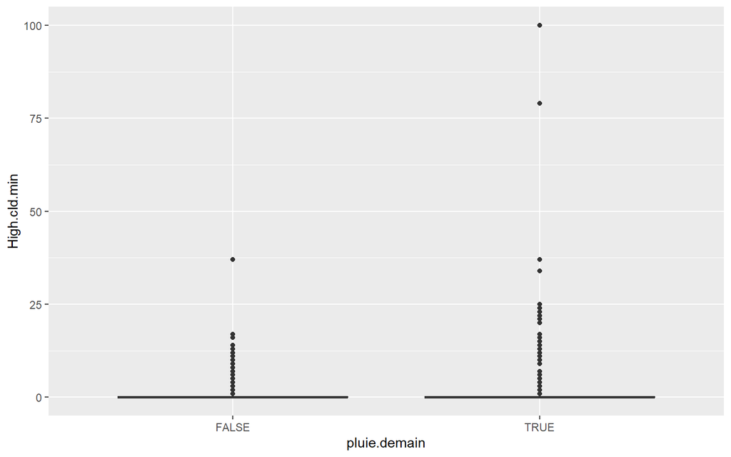

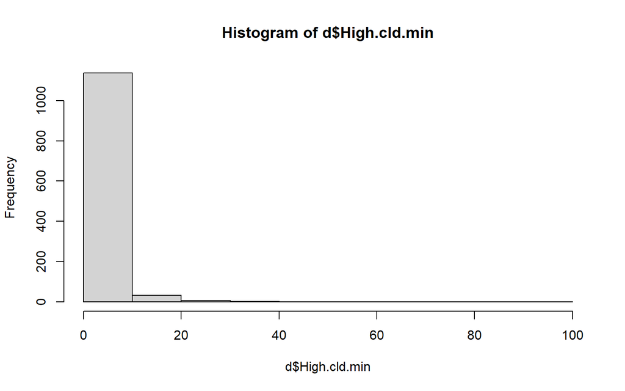

```r
ggplot(d, aes(x=pluie.demain, y=High.cld.min)) + geom_boxplot()
hist(d$High.cld.min)
```

#### Variable Precip

Nous utilisons la même logique que pour la variable High.cld.min pour déterminer l’utilité de la variable precip.

Sur l’histogramme nous voyons que la plupart des observations sont concentrées vers la gauche cependant le boxplot montre que la variable precip semble donner des indications sur pluie.demain.

Interprétation : les observations avec pluie.demain = TRUE ont tendance à avoir un niveau de précipitation supérieur à 0.

=> on conserve la variable

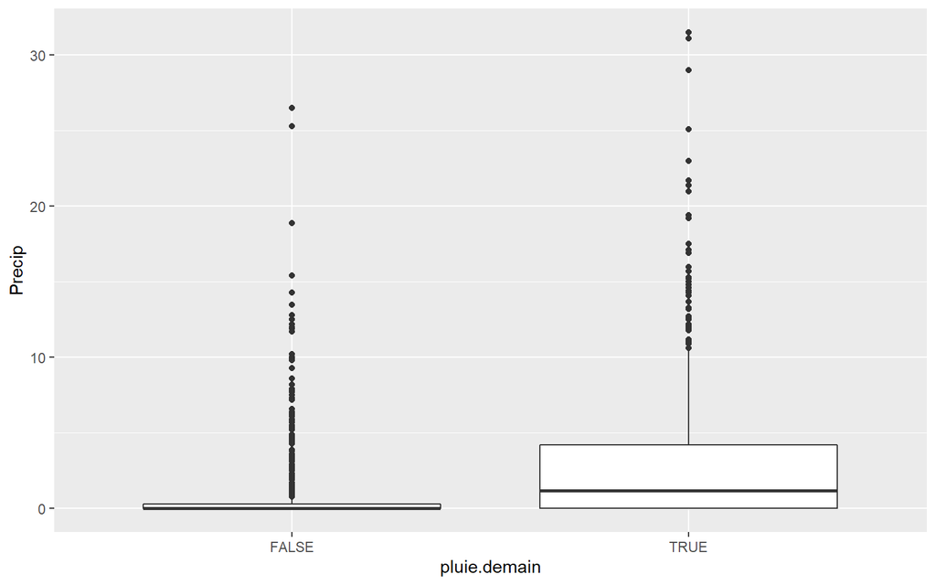

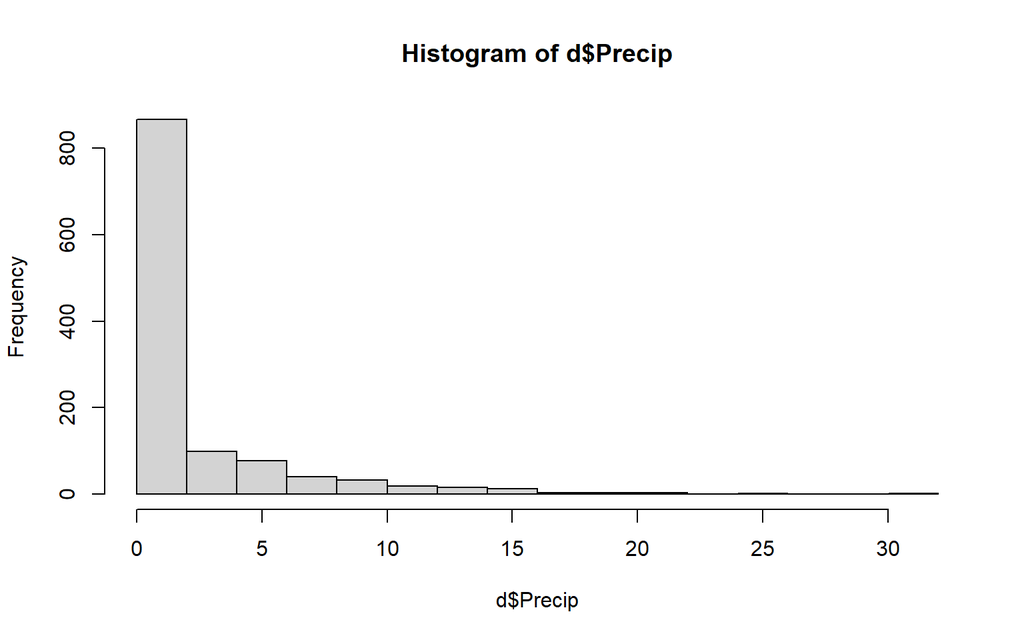

```r
ggplot(d, aes(x=pluie.demain, y=Precip)) + geom_boxplot()
hist(d$Precip)
```

#### Variable Snowfall

Même raisonnement pour la variable Snowfall

=> on élimine la variable

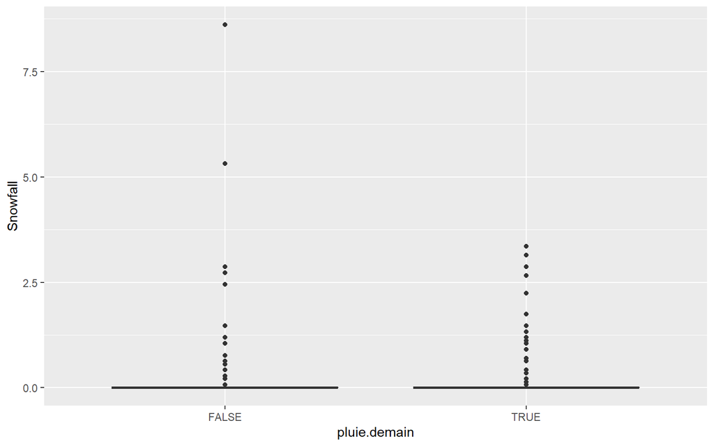

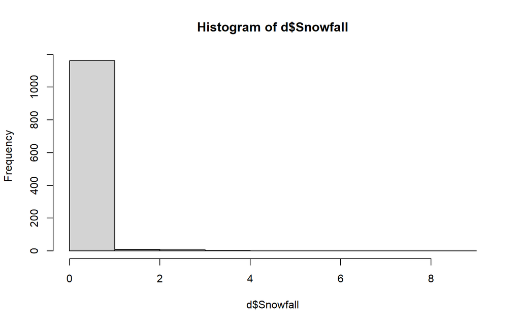

```r
ggplot(d, aes(x=pluie.demain, y=Snowfall)) + geom_boxplot()
hist(d$Snowfall)
```

#### Variable Total.cld.min

Même raisonnement pour la variable Total.cld.min

=> on conserve la variable

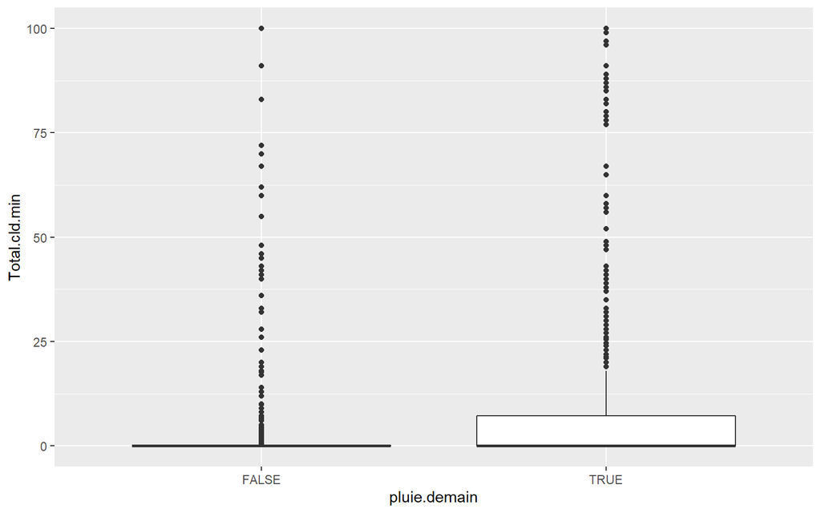

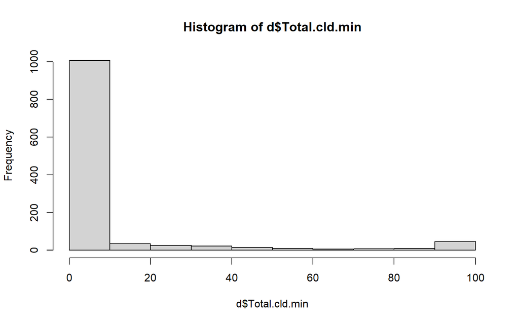

```r
ggplot(d, aes(x=pluie.demain, y=Total.cld.min)) + geom_boxplot()
hist(d$Total.cld.min)
```

#### Variable Total.cld.max

=> on élimine la variable

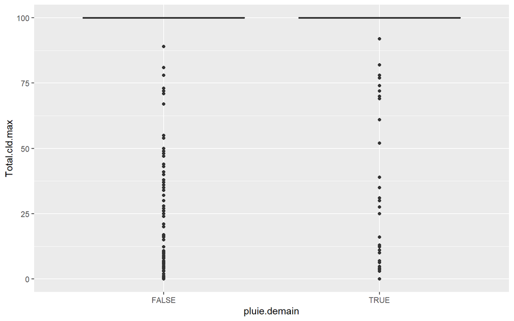

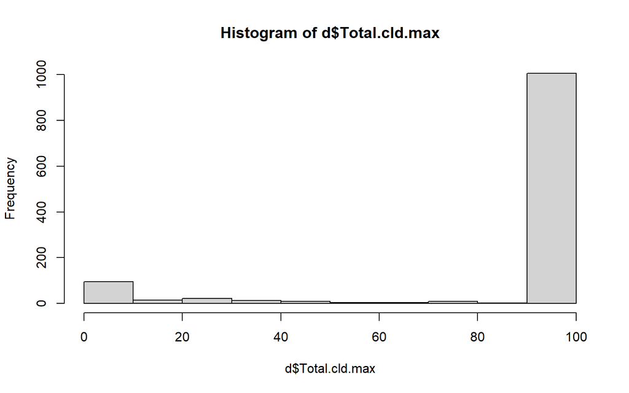

```r
ggplot(d, aes(x=pluie.demain, y=Total.cld.max)) + geom_boxplot()
hist(d$Total.cld.max)
```

#### Variable Med.cld.min

=> on élimine la variable

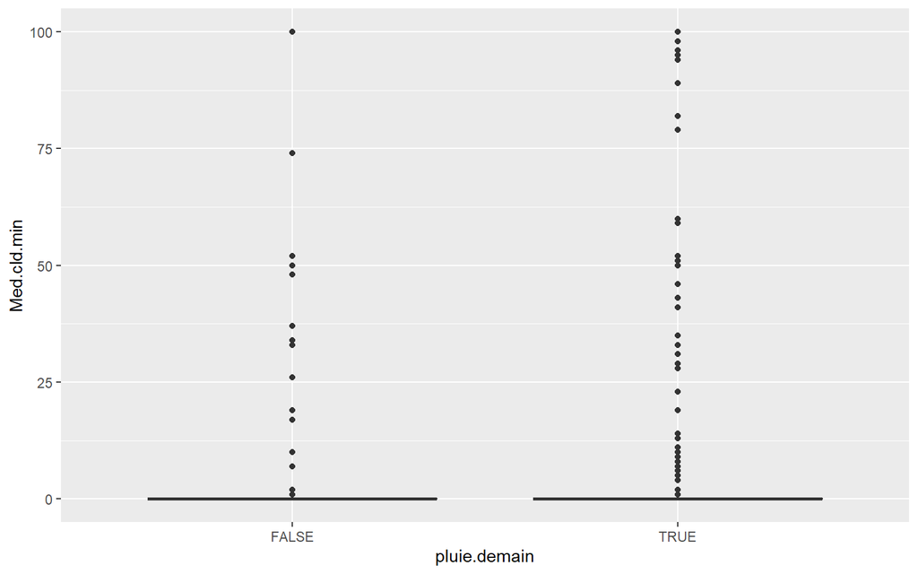

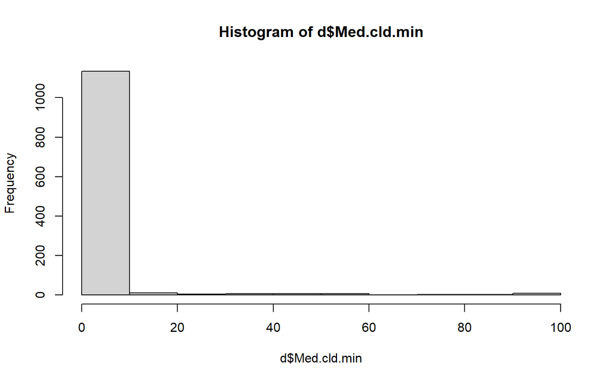

```r
ggplot(d, aes(x=pluie.demain, y=Med.cld.min )) + geom_boxplot()
hist(d$Med.cld.min)
```

#### Variable Med.cld.max

=> on conserve la variable

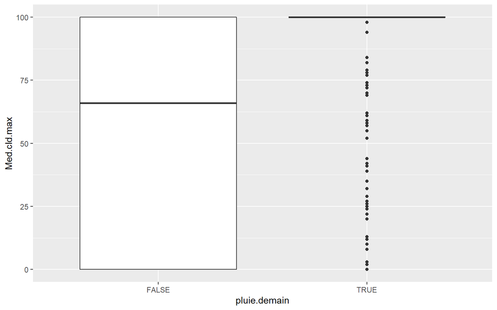

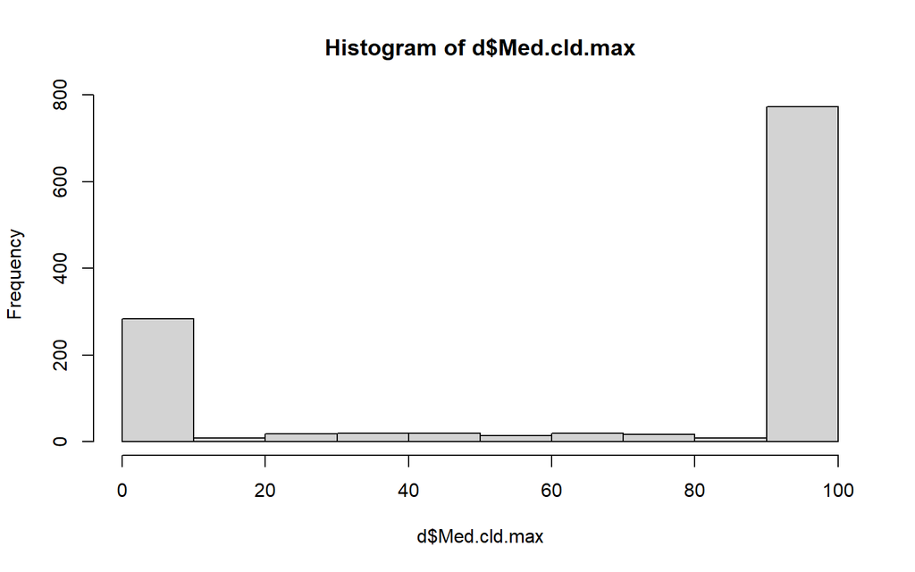

```r
ggplot(d, aes(x=pluie.demain, y=Med.cld.max )) + geom_boxplot()
hist(d$Med.cld.max)
```

#### Variable Low.cld.min

=> on élimine la variable

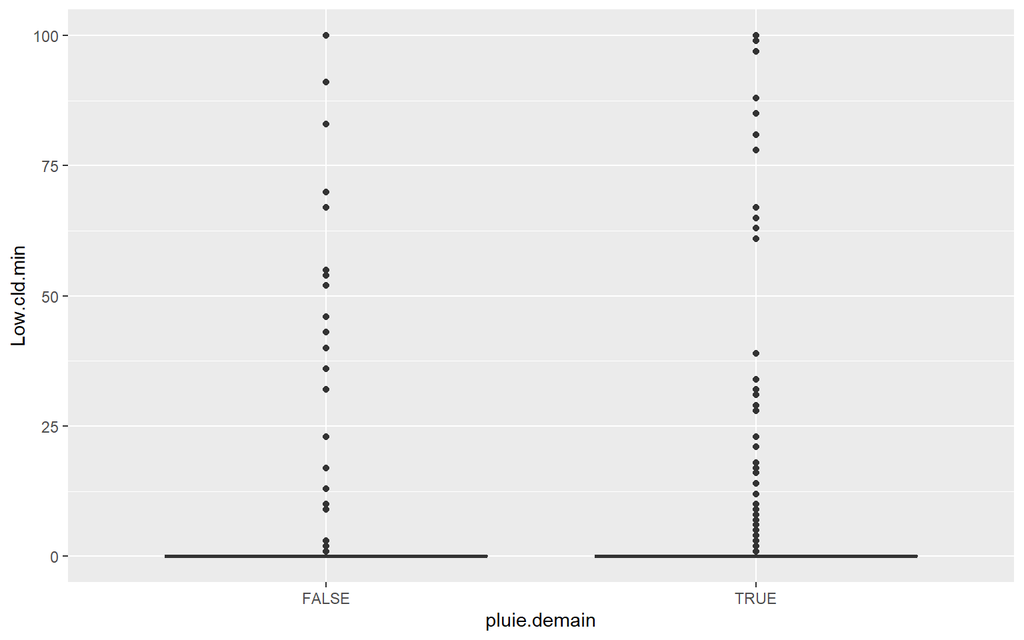

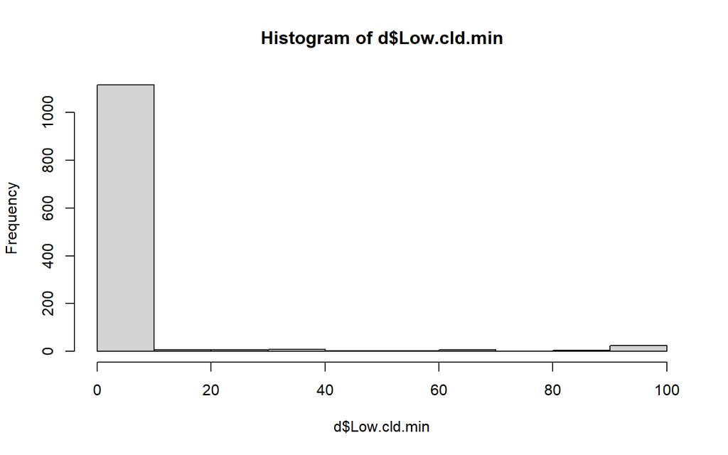

```r
ggplot(d, aes(x=pluie.demain, y=Low.cld.min )) + geom_boxplot()
hist(d$Low.cld.min)
```

#### Variable Low.cld.max

=> on conserve la variable

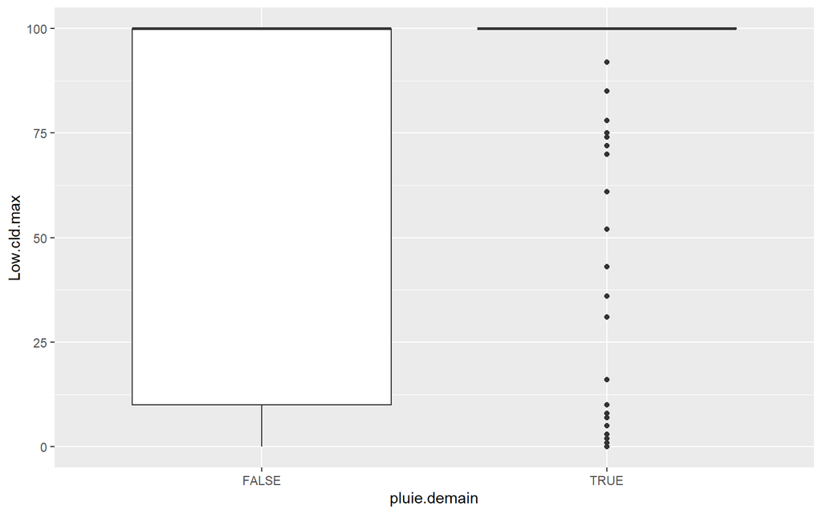

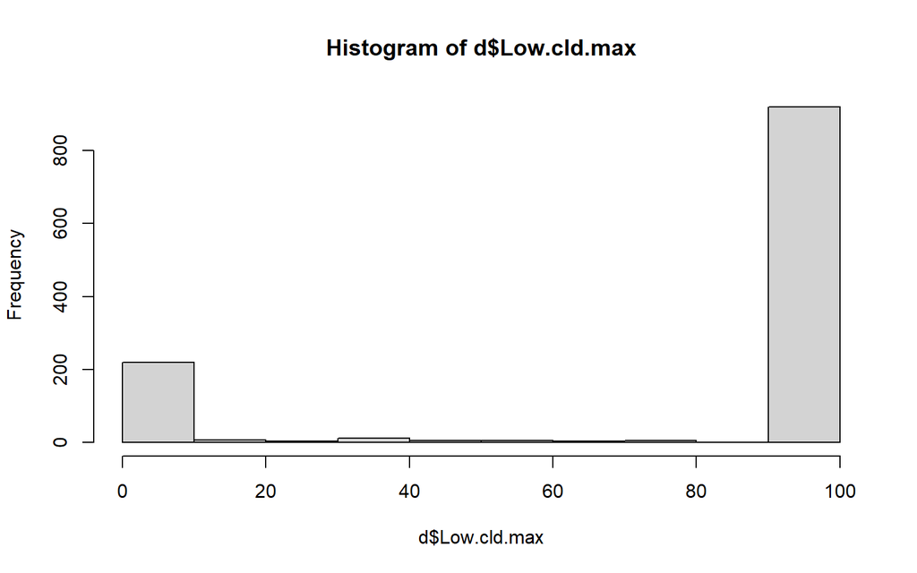

```r
ggplot(d, aes(x=pluie.demain, y=Low.cld.max )) + geom_boxplot()
hist(d$Low.cld.max)
```

#### Variable Pressure

Pour la pression nous regardons la corrélation entre Pressure.max, Pressure.min, Pressure.mean. Ces variables sont fortement corrélées. Nous décidons donc de ne garder que la pression moyenne Pressure.mean et ajouter une variable (Pressure.max-Pressure.min) pour essayer de capter les jours avec des gros changements de pression. Nous pensons un gros changement de pression peut amener une situation orageuse et donc de la pluie.

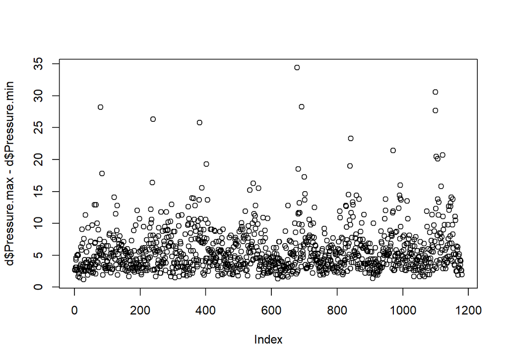

```r
plot(d$Pressure.max - d$Pressure.min)
```

```r
temp = data.frame(d$Pressure.max,d$Pressure.min,d$Pressure.mean,d$Pressure.max - d$Pressure.min )
cor(temp)
```

```
##                                 d.Pressure.max d.Pressure.min d.Pressure.mean
## d.Pressure.max                     1.000000000      0.9047461       0.9722008
## d.Pressure.min                     0.904746052      1.0000000       0.9735478
## d.Pressure.mean                    0.972200761      0.9735478       1.0000000
## d.Pressure.max...d.Pressure.min   -0.009935123     -0.4349191      -0.2302201
##                                 d.Pressure.max...d.Pressure.min
## d.Pressure.max                                     -0.009935123
## d.Pressure.min                                     -0.434919125
## d.Pressure.mean                                    -0.230220060
## d.Pressure.max...d.Pressure.min                     1.000000000
```

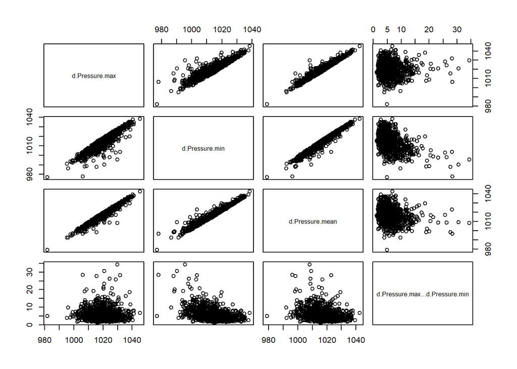

```r
pairs(temp)
```

#### Ajout des variables Gust.var et Pressure.var

Comme pour la variation de pression, nous décidons d’ajouter la variation des rafales (Gust.var) pour capter les évènements orageux.

```r
d["Gust.var"] = d$Gust.max -d$Gust.min
d["Pressure.var"] = d$Pressure.max - d$Pressure.min
```

et on supprime les variables sélectionnées ci-dessus.

```r
d = d[,-which(names(d) %in% c(
  "High.cld.min","Snowfall","Total.cld.max","Med.cld.min","Low.cld.min","Pressure.max","Pressure.min"
          ))]
```

## 2.2 - Analyse corrélation

Après avoir retiré les variables qui ne semblent pas importer d’information dans le modèle, nous allons retirer les variables avec une forte corrélation. Nous souhaitons garder des variables uniques et éviter la redondance dans le modèle c’est pourquoi nous décidons de supprimer toutes les variables avec une corrélation de plus de 0.90 en valeur absolue. Le seuil de 0.90 est arbitraire

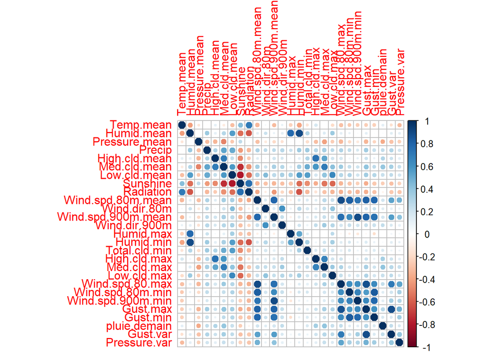

```r
dfcor = abs(cor(d))
hc = findCorrelation(dfcor, cutoff=0.90) # putt any value as a "cutoff"
hc = sort(hc)
reduced_Data = d[,-c(hc)]
#print (reduced_Data)
d = reduced_Data
corrplot(cor(d, use="complete"))
```

Grace aux manipulations ci-dessus nous avons réussi à réduire la dimension et allons maintenant pouvoir utiliser plus sereinement des algorithmes de sélection des variables.

# 3 - Choix du modèle

Le modèle saturé comporte un nombre élevé de variables. Utiliser ce modèle pourrait nous apporter de très bons résultats sur notre échantillon d’apprentissage mais entrainera probablement du sur apprentissage sur un échantillon de test.

Nous allons donc utiliser la fonction step avec le critère les critères d’AIC (modèle 1) et BIC (modèle 2) pour sélectionner deux modèles. Nous créerons ensuite un troisième modèle (modèle 3) qui sera une combinaison des variables présentes dans les modèles 1 et 2 en ajoutant des relations entre celles-ci. Notre objectif est d’obtenir un résultat convenable du point de vue AIC / BIC et ne pas prendre un modèle avec un nombre élevé de variables.

## 3.0 - modèle saturé

Le modèle saturé comporte un très grand nombre de variables.

L’objectif est donc de trouver un modèle qui sera meilleur que celui ci du point au niveau des limites AIC / BIC.

AIC modèle saturé = 1327.9

BIC modèle saturé = 1459.842

```r
glm1 <- glm(pluie.demain ~ ., family = binomial, data = d)
BIC(glm1)
```

```
## [1] 1459.842
```

```r
glm0 <- glm(pluie.demain ~ 1, family = binomial, data = d)
summary(glm1)
```

```
##
## Call:
## glm(formula = pluie.demain ~ ., family = binomial, data = d)
##
## Deviance Residuals:
##     Min       1Q   Median       3Q      Max
## -2.3601  -0.8615   0.3550   0.8587   2.7821
##
## Coefficients: (1 not defined because of singularities)
##                      Estimate Std. Error z value Pr(>|z|)
## (Intercept)         5.210e+01  1.175e+01   4.435 9.19e-06 ***
## Temp.mean           3.394e-02  1.771e-02   1.916  0.05532 .
## Humid.mean          1.993e-02  2.966e-02   0.672  0.50173
## Pressure.mean      -5.537e-02  1.141e-02  -4.854 1.21e-06 ***
## Precip              6.789e-03  2.471e-02   0.275  0.78352
## High.cld.mean      -1.256e-03  6.039e-03  -0.208  0.83522
## Med.cld.mean        5.303e-03  5.269e-03   1.007  0.31414
## Low.cld.mean        2.586e-03  5.136e-03   0.503  0.61462
## Sunshine           -2.958e-04  6.773e-04  -0.437  0.66230
## Radiation           1.378e-04  7.998e-05   1.723  0.08488 .
## Wind.spd.80m.mean  -7.918e-02  3.473e-02  -2.280  0.02263 *
## Wind.dir.80m       -4.065e-03  1.610e-03  -2.525  0.01158 *
## Wind.spd.900m.mean  5.631e-03  1.418e-02   0.397  0.69135
## Wind.dir.900m       5.137e-03  1.335e-03   3.847  0.00012 ***
## Humid.max           5.749e-03  1.906e-02   0.302  0.76297
## Humid.min          -1.904e-02  1.618e-02  -1.177  0.23938
## Total.cld.min       7.277e-03  4.209e-03   1.729  0.08382 .
## High.cld.max        3.265e-03  2.765e-03   1.181  0.23762
## Med.cld.max         8.284e-03  2.691e-03   3.079  0.00208 **
## Low.cld.max         3.634e-03  2.575e-03   1.411  0.15819
## Wind.spd.80.max     3.114e-02  2.084e-02   1.495  0.13503
## Wind.spd.80m.min    8.868e-03  2.939e-02   0.302  0.76285
## Wind.spd.900m.min  -7.997e-03  1.612e-02  -0.496  0.61984
## Gust.max            2.249e-02  1.190e-02   1.889  0.05885 .
## Gust.min            3.886e-02  2.301e-02   1.689  0.09127 .
## Gust.var                   NA         NA      NA       NA
## Pressure.var        3.578e-02  2.410e-02   1.484  0.13771
## ---
## Signif. codes:  0 '***' 0.001 '**' 0.01 '*' 0.05 '.' 0.1 ' ' 1
##
## (Dispersion parameter for binomial family taken to be 1)
##
##     Null deviance: 1635.4  on 1179  degrees of freedom
## Residual deviance: 1275.9  on 1154  degrees of freedom
## AIC: 1327.9
##
## Number of Fisher Scoring iterations: 4
```

## 3.1 - Modèle 1 step AIC sens both

```r
Step.logit.AIC.both = step(glm1,direction='both')
```

```r
Step.logit.AIC.both.glm = glm(pluie.demain ~
                      Temp.mean + Humid.mean + Pressure.mean + Med.cld.mean +
                      Radiation + Wind.spd.80m.mean + Wind.dir.80m + Wind.dir.900m +
                      Humid.min + Total.cld.min + Med.cld.max + Low.cld.max + Wind.spd.80.max +
                      Gust.max + Gust.min + Pressure.var
  , family = binomial, data = d)
summary(Step.logit.AIC.both.glm)
```

```
##
## Call:
## glm(formula = pluie.demain ~ Temp.mean + Humid.mean + Pressure.mean +
##     Med.cld.mean + Radiation + Wind.spd.80m.mean + Wind.dir.80m +
##     Wind.dir.900m + Humid.min + Total.cld.min + Med.cld.max +
##     Low.cld.max + Wind.spd.80.max + Gust.max + Gust.min + Pressure.var,
##     family = binomial, data = d)
##
## Deviance Residuals:
##     Min       1Q   Median       3Q      Max
## -2.3573  -0.8764   0.3552   0.8566   2.7546
##
## Coefficients:
##                     Estimate Std. Error z value Pr(>|z|)
## (Intercept)        5.137e+01  1.152e+01   4.460 8.21e-06 ***
## Temp.mean          3.864e-02  1.640e-02   2.355  0.01850 *
## Humid.mean         3.081e-02  1.765e-02   1.746  0.08086 .
## Pressure.mean     -5.483e-02  1.119e-02  -4.900 9.61e-07 ***
## Med.cld.mean       7.868e-03  4.111e-03   1.914  0.05564 .
## Radiation          1.105e-04  6.519e-05   1.696  0.08993 .
## Wind.spd.80m.mean -7.577e-02  2.759e-02  -2.747  0.00602 **
## Wind.dir.80m      -3.837e-03  1.569e-03  -2.445  0.01447 *
## Wind.dir.900m      5.212e-03  1.324e-03   3.935 8.30e-05 ***
## Humid.min         -2.255e-02  1.371e-02  -1.644  0.10009
## Total.cld.min      8.619e-03  3.816e-03   2.259  0.02390 *
## Med.cld.max        9.787e-03  2.370e-03   4.130 3.63e-05 ***
## Low.cld.max        4.432e-03  2.265e-03   1.957  0.05039 .
## Wind.spd.80.max    3.059e-02  1.923e-02   1.591  0.11165
## Gust.max           2.388e-02  1.033e-02   2.311  0.02086 *
## Gust.min           3.950e-02  1.770e-02   2.232  0.02565 *
## Pressure.var       3.689e-02  2.398e-02   1.538  0.12395
## ---
## Signif. codes:  0 '***' 0.001 '**' 0.01 '*' 0.05 '.' 0.1 ' ' 1
##
## (Dispersion parameter for binomial family taken to be 1)
##
##     Null deviance: 1635.4  on 1179  degrees of freedom
## Residual deviance: 1279.2  on 1163  degrees of freedom
## AIC: 1313.2
##
## Number of Fisher Scoring iterations: 4
```

```r
BIC(Step.logit.AIC.both.glm)
```

```
## [1] 1399.4
```

```r
#analyse de la deviance
# Comparaison au modèle sans covariables
pchisq(1635.4 - 1279.2  , 1179 - 1163, lower = F)
```

```
## [1] 5.268427e-66
```

```r
# Comparaison au modèle saturé
pchisq(1279.2, 1163, lower = F)
```

```
## [1] 0.00945751
```

AIC modèle 1: 1313.2

BIC modèle 1: 1399.4

Il performe mieux que le modèle saturé du point de vue de l’AIC et du BIC.

En comparant notre modèle à celui sans covariables on obtient une p value très faible (5.268427e-66) . On rejette donc le modèle sans covariable et on estime que le modèle 1 est plus utile

On compare ensuite notre modèle avec le modèle saturé. La pvalue est faible. Le modèle saturé à un meilleur résultat que le modèle 1. On rejette donc notre modèle et on préfère le modèle saturé sur ce critère.

## 3.2 - Modèle 2 step BIC sens both

```r
Step.logit.BIC.both = step(glm1,direction='both',k = log(1180))
```

```r
Step.logit.BIC.both.glm = glm(pluie.demain ~
                      Temp.mean + Pressure.mean + Wind.dir.900m + Med.cld.max +
                      Gust.max + Med.cld.mean

  , family = binomial, data = d)
summary(Step.logit.BIC.both.glm)
```

```
##
## Call:
## glm(formula = pluie.demain ~ Temp.mean + Pressure.mean + Wind.dir.900m +
##     Med.cld.max + Gust.max + Med.cld.mean, family = binomial,
##     data = d)
##
## Deviance Residuals:
##     Min       1Q   Median       3Q      Max
## -2.2658  -0.8941   0.3874   0.8656   2.5113
##
## Coefficients:
##                 Estimate Std. Error z value Pr(>|z|)
## (Intercept)   56.2707026 11.0553507   5.090 3.58e-07 ***
## Temp.mean      0.0501734  0.0107361   4.673 2.96e-06 ***
## Pressure.mean -0.0580975  0.0107983  -5.380 7.44e-08 ***
## Wind.dir.900m  0.0026159  0.0009756   2.681  0.00733 **
## Med.cld.max    0.0097901  0.0022863   4.282 1.85e-05 ***
## Gust.max       0.0234410  0.0056230   4.169 3.06e-05 ***
## Med.cld.mean   0.0094936  0.0034083   2.785  0.00535 **
## ---
## Signif. codes:  0 '***' 0.001 '**' 0.01 '*' 0.05 '.' 0.1 ' ' 1
##
## (Dispersion parameter for binomial family taken to be 1)
##
##     Null deviance: 1635.4  on 1179  degrees of freedom
## Residual deviance: 1306.4  on 1173  degrees of freedom
## AIC: 1320.4
##
## Number of Fisher Scoring iterations: 4
```

```r
BIC(Step.logit.BIC.both.glm)
```

```
## [1] 1355.961
```

```r
#analyse de la deviance
# Comparaison au modèle sans covariables
pchisq(1635.4 - 1306.4  , 1179 - 1173, lower = F)
```

```
## [1] 4.956095e-68
```

```r
# Comparaison au modèle saturé
pchisq(1306.4, 1173, lower = F)
```

```
## [1] 0.003794474
```

Le modèle 2 (Step.logit.BIC.both.glm) est composé de 6 variables explicatives.

AIC modèle 2: 1320.4 (modèle 1 = 1313.2)

BIC modèle 2: 1355.9 (modèle 1 = 1399.4)

On compare ensuite notre modèle avec le modèle saturé. La pvalue est faible (0.003794474). Le modèle saturé à un meilleur résultat que le modèle 2. On rejette donc notre modèle et on préfère le modèle saturé sur ce critère.

Il est intéressant de noter que les variables sélectionnées dans le modèle 2 sont présentes dans le modèle 1.

## 3.3 - Modèle 3 intégration de l’interaction des variables

Pour trouver ce modèle nous avons utilisé les variables communes de modèles 1 et 2 et cherché manuellement les combinaisons de variables qui pouvaient apporter de l’information.

Après test de plusieurs variables nous avons obtenu le modèle ci dessous (modèle 3 = Base.BIC.interaction)

Par rapport au modèle 2 basé nous avons ajouté les combinaisons suivantes:

Temp.mean:Pressure.mean  
Temp.mean:Wind.dir.900m Temp.mean:Med.cld.max  
Temp.mean:Gust.max  
Med.cld.max:Gust.max  
Med.cld.max:Med.cld.mean  
Gust.max:Med.cld.mean

```r
Base.BIC.interaction.glm = glm(pluie.demain ~
Pressure.mean
+Temp.mean
+Wind.dir.900m
+Med.cld.max
+Gust.max
+Med.cld.mean
+Temp.mean:Pressure.mean
+Temp.mean:Wind.dir.900m
+Temp.mean:Med.cld.max
+Temp.mean:Gust.max
+Med.cld.max:Gust.max
+Med.cld.max:Med.cld.mean
+Gust.max:Med.cld.mean
, family = binomial, data = d)
summary(Base.BIC.interaction.glm)
```

```
##
## Call:
## glm(formula = pluie.demain ~ Pressure.mean + Temp.mean + Wind.dir.900m +
##     Med.cld.max + Gust.max + Med.cld.mean + Temp.mean:Pressure.mean +
##     Temp.mean:Wind.dir.900m + Temp.mean:Med.cld.max + Temp.mean:Gust.max +
##     Med.cld.max:Gust.max + Med.cld.max:Med.cld.mean + Gust.max:Med.cld.mean,
##     family = binomial, data = d)
##
## Deviance Residuals:
##     Min       1Q   Median       3Q      Max
## -2.2386  -0.7940   0.3184   0.8144   2.3598
##
## Coefficients:
##                            Estimate Std. Error z value Pr(>|z|)
## (Intercept)              -2.435e+01  1.823e+01  -1.336 0.181563
## Pressure.mean             2.011e-02  1.776e-02   1.132 0.257492
## Temp.mean                 1.066e+01  1.870e+00   5.699 1.20e-08 ***
## Wind.dir.900m             9.501e-03  1.968e-03   4.829 1.37e-06 ***
## Med.cld.max              -1.521e-02  7.710e-03  -1.972 0.048584 *
## Gust.max                  3.784e-02  1.721e-02   2.199 0.027883 *
## Med.cld.mean              1.635e-01  7.941e-02   2.058 0.039544 *
## Pressure.mean:Temp.mean  -1.030e-02  1.830e-03  -5.628 1.83e-08 ***
## Temp.mean:Wind.dir.900m  -5.580e-04  1.476e-04  -3.779 0.000157 ***
## Temp.mean:Med.cld.max     1.006e-03  2.875e-04   3.500 0.000465 ***
## Temp.mean:Gust.max       -3.425e-03  8.805e-04  -3.890 0.000100 ***
## Med.cld.max:Gust.max      4.443e-04  2.134e-04   2.082 0.037364 *
## Med.cld.max:Med.cld.mean -1.377e-03  7.755e-04  -1.776 0.075794 .
## Gust.max:Med.cld.mean    -4.706e-04  2.504e-04  -1.879 0.060204 .
## ---
## Signif. codes:  0 '***' 0.001 '**' 0.01 '*' 0.05 '.' 0.1 ' ' 1
##
## (Dispersion parameter for binomial family taken to be 1)
##
##     Null deviance: 1635.4  on 1179  degrees of freedom
## Residual deviance: 1230.7  on 1166  degrees of freedom
## AIC: 1258.7
##
## Number of Fisher Scoring iterations: 4
```

```r
BIC(Base.BIC.interaction.glm)
```

```
## [1] 1329.709
```

```r
#analyse de la deviance
# Comparaison au modèle sans covariables
pchisq(1635.4 - 1230.7      , 1179 - 1166    , lower = F)
```

```
## [1] 2.273875e-78
```

```r
# Comparaison au modèle saturé
pchisq(1230.7    , 1166    , lower = F)
```

```
## [1] 0.09183588
```

Le modèle 3 (Base.BIC.interaction) est composé de 6 variables explicatives.

AIC modèle 3: 1258.7 (modèle 1 = 1313.2, modèle 2 = 1320.4)

Au niveau de l’AIC et BIC le troisième modèle est le plus performant.

Description des variables du modèle :

La température moyenne (Temp.mean) et la couverture nuageuse à moyennes altitude (Med.cld.mean) sont les événements qui tendent le plus à faire augmenter la probabilité que pluie.demain soit positif.

# 4 - Comparaison de la performance de prédiction

Nous allons maintenant faire une validation croisée des trois modèles et analyser les résultats pour voir le plus performant

```r
k = 10
index = sample(1:k, nrow(d), replace=T)
```

## 4.1 - Modèle 1 step AIC sens both

```r
res.logistique = rep(NA, k)
res.probit = rep(NA, k)
res.logistique.label = rep(NA, k)
res.probit.label = rep(NA, k)

for(i in 1:k){

    #regression logistque
   reg.logistique = glm(
     pluie.demain ~
       Temp.mean + Humid.mean + Pressure.mean + Med.cld.mean +
                      Radiation + Wind.spd.80m.mean + Wind.dir.80m + Wind.dir.900m +
                      Humid.min + Total.cld.min + Med.cld.max + Low.cld.max + Wind.spd.80.max +
                      Gust.max + Gust.min + Pressure.var

      ,
    data = d[index != i, ]
  )

  #regression probit
  reg.probit = glm(
    pluie.demain  ~
     Temp.mean + Humid.mean + Pressure.mean + Med.cld.mean +
                      Radiation + Wind.spd.80m.mean + Wind.dir.80m + Wind.dir.900m +
                      Humid.min + Total.cld.min + Med.cld.max + Low.cld.max + Wind.spd.80.max +
                      Gust.max + Gust.min + Pressure.var
    ,
    family = binomial(link="probit"),
    data = d[index != i, ]
  )

  pred.logistique = predict(reg.logistique, newdata=d[index == i, ],type="response")
  pred.logistique.label = (pred.logistique >= 0.5)

  pred.probit = predict(reg.probit, newdata=d[index == i, ],type="response")
  pred.probit.label = (pred.probit >= 0.5)


  res.logistique[i] = mean(d[index==i, TRUE] == (pred.logistique >.5), na.rm = T)
  res.logistique.label[i] = mean(pred.logistique.label == d$pluie.demain[index==i])

  res.probit[i] = mean(d[index==i, TRUE] == (pred.probit >.5), na.rm = T)
  res.probit.label[i] = mean(pred.probit.label == d$pluie.demain[index==i])

}

#mean(res.logistique)
mean(res.logistique.label)
```

```
## [1] 0.7135782
```

```r
(var(res.logistique.label)^0.5)/mean(res.logistique.label)
```

```
## [1] 0.0510411
```

```r
#mean(res.probit)
mean(res.probit.label)
```

```
## [1] 0.712273
```

```r
(var(res.probit.label)^0.5)/mean(res.probit.label)
```

```
## [1] 0.05898451
```

Modèle 1 - Probit

Taux de bonnes réponses 71.2%

## 4.2 - Modèle 2 step BIC sens both

```r
res.logistique = rep(NA, k)
res.probit = rep(NA, k)
res.logistique.label = rep(NA, k)
res.probit.label = rep(NA, k)

for(i in 1:k){

    #regression logistque
   reg.logistique = glm(
     pluie.demain ~
       Temp.mean + Pressure.mean + Wind.dir.900m + Med.cld.max +
                      Gust.max + Med.cld.mean

      ,
    data = d[index != i, ]
  )

  #regression probit
  reg.probit = glm(
    pluie.demain  ~
       Temp.mean + Pressure.mean + Wind.dir.900m + Med.cld.max +
                      Gust.max + Med.cld.mean,
    family = binomial(link="probit"),
    data = d[index != i, ]
  )

  pred.logistique = predict(reg.logistique, newdata=d[index == i, ],type="response")
  pred.logistique.label = (pred.logistique >= 0.5)

  pred.probit = predict(reg.probit, newdata=d[index == i, ],type="response")
  pred.probit.label = (pred.probit >= 0.5)


  res.logistique[i] = mean(d[index==i, TRUE] == (pred.logistique >.5), na.rm = T)
  res.logistique.label[i] = mean(pred.logistique.label == d$pluie.demain[index==i])

  res.probit[i] = mean(d[index==i, TRUE] == (pred.probit >.5), na.rm = T)
  res.probit.label[i] = mean(pred.probit.label == d$pluie.demain[index==i])

}

#mean(res.logistique)
mean(res.logistique.label)
```

```
## [1] 0.7234877
```

```r
var(res.logistique.label)^0.5
```

```
## [1] 0.03506872
```

```r
#mean(res.probit)
mean(res.probit.label)
```

```
## [1] 0.7261799
```

```r
var(res.probit.label)^0.5
```

```
## [1] 0.03311846
```

Taux de bonnes réponses 72.4%

Modèle 2 - Probit

## 4.3 - Modèle 3 intégration de l’interaction des variable

```r
res.logistique = rep(NA, k)
res.probit = rep(NA, k)
res.logistique.label = rep(NA, k)
res.probit.label = rep(NA, k)

for(i in 1:k){

    #regression logistque
   reg.logistique = glm(
     pluie.demain ~
Pressure.mean
+Temp.mean
+Wind.dir.900m
+Med.cld.max
+Gust.max
+Med.cld.mean
+Temp.mean:Pressure.mean
+Temp.mean:Wind.dir.900m
+Temp.mean:Med.cld.max
+Temp.mean:Gust.max
+Med.cld.max:Gust.max
+Med.cld.max:Med.cld.mean
+Gust.max:Med.cld.mean


      ,
    data = d[index != i, ]
  )

  #regression probit
  reg.probit = glm(
    pluie.demain  ~
Pressure.mean
+Temp.mean
+Wind.dir.900m
+Med.cld.max
+Gust.max
+Med.cld.mean
+Temp.mean:Pressure.mean
+Temp.mean:Wind.dir.900m
+Temp.mean:Med.cld.max
+Temp.mean:Gust.max
+Med.cld.max:Gust.max
+Med.cld.max:Med.cld.mean
+Gust.max:Med.cld.mean
    ,
    family = binomial(link="probit"),
    data = d[index != i, ]
  )

  pred.logistique = predict(reg.logistique, newdata=d[index == i, ],type="response")
  pred.logistique.label = (pred.logistique >= 0.5)

  pred.probit = predict(reg.probit, newdata=d[index == i, ],type="response")
  pred.probit.label = (pred.probit >= 0.5)


#  res.logistique[i] = mean(d[index==i, TRUE] == (pred.logistique >.5), na.rm = T)
  res.logistique.label[i] = mean(pred.logistique.label == d$pluie.demain[index==i])

#  res.probit[i] = mean(d[index==i, TRUE] == (pred.probit >.5), na.rm = T)
  res.probit.label[i] = mean(pred.probit.label == d$pluie.demain[index==i])

}

#mean(res.logistique)
mean(res.logistique.label)
```

```
## [1] 0.7336988
```

```r
var(res.logistique.label)^0.5
```

```
## [1] 0.0470076
```

```r
#mean(res.probit)
mean(res.probit.label)
```

```
## [1] 0.7379433
```

```r
var(res.probit.label)^0.5
```

```
## [1] 0.04462105
```

Modèle 3 - Probit

## 4.4 - Choix du modèle pour la prédiction

Nous décidons de selectionner le modèle 3 en Logit pour la prédiction de pluie.demain dans du fichier test.

La courbe ROC ci dessous nous montre que le modèle 3 performe égalemment mieux que l’aléatoire. Il nous semble donc pertinent de le sélectionner.

```r
prob=pred.logistique
g <- roc(pluie.demain ~ prob, data = d[index == i, ])
```

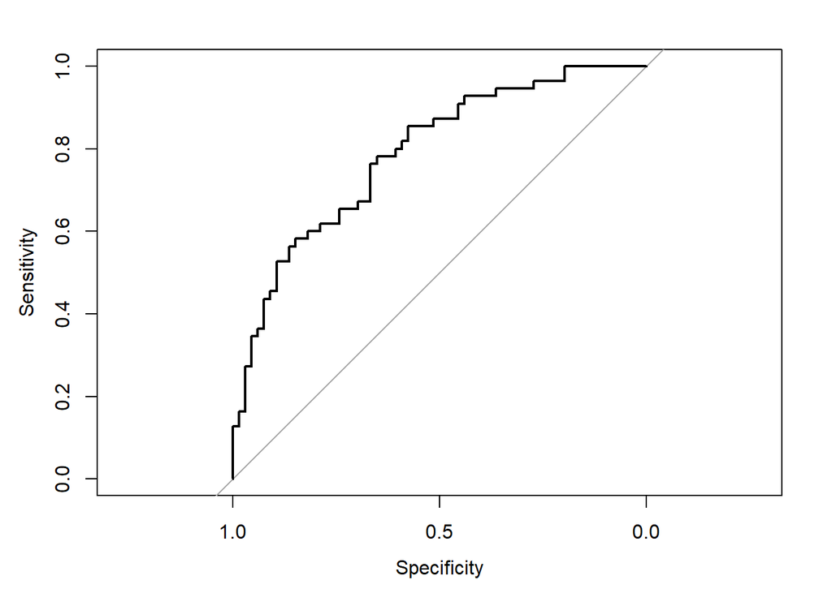

```r
plot(g)
```

# 5 - Prédiction avec le modèle 3: Base.BIC.interaction

## 5.1 - Rappel du modèle

Le modèle selectionné pour la prédiction est le suivant:

```r
model.prediction = glm(pluie.demain ~
  Pressure.mean
+Temp.mean
+Wind.dir.900m
+Med.cld.max
+Gust.max
+Med.cld.mean
+Temp.mean:Pressure.mean
+Temp.mean:Wind.dir.900m
+Temp.mean:Med.cld.max
+Temp.mean:Gust.max
+Med.cld.max:Gust.max
+Med.cld.max:Med.cld.mean
+Gust.max:Med.cld.mean
, family = binomial, data = d)

summary(model.prediction)
```

```
##
## Call:
## glm(formula = pluie.demain ~ Pressure.mean + Temp.mean + Wind.dir.900m +
##     Med.cld.max + Gust.max + Med.cld.mean + Temp.mean:Pressure.mean +
##     Temp.mean:Wind.dir.900m + Temp.mean:Med.cld.max + Temp.mean:Gust.max +
##     Med.cld.max:Gust.max + Med.cld.max:Med.cld.mean + Gust.max:Med.cld.mean,
##     family = binomial, data = d)
##
## Deviance Residuals:
##     Min       1Q   Median       3Q      Max
## -2.2386  -0.7940   0.3184   0.8144   2.3598
##
## Coefficients:
##                            Estimate Std. Error z value Pr(>|z|)
## (Intercept)              -2.435e+01  1.823e+01  -1.336 0.181563
## Pressure.mean             2.011e-02  1.776e-02   1.132 0.257492
## Temp.mean                 1.066e+01  1.870e+00   5.699 1.20e-08 ***
## Wind.dir.900m             9.501e-03  1.968e-03   4.829 1.37e-06 ***
## Med.cld.max              -1.521e-02  7.710e-03  -1.972 0.048584 *
## Gust.max                  3.784e-02  1.721e-02   2.199 0.027883 *
## Med.cld.mean              1.635e-01  7.941e-02   2.058 0.039544 *
## Pressure.mean:Temp.mean  -1.030e-02  1.830e-03  -5.628 1.83e-08 ***
## Temp.mean:Wind.dir.900m  -5.580e-04  1.476e-04  -3.779 0.000157 ***
## Temp.mean:Med.cld.max     1.006e-03  2.875e-04   3.500 0.000465 ***
## Temp.mean:Gust.max       -3.425e-03  8.805e-04  -3.890 0.000100 ***
## Med.cld.max:Gust.max      4.443e-04  2.134e-04   2.082 0.037364 *
## Med.cld.max:Med.cld.mean -1.377e-03  7.755e-04  -1.776 0.075794 .
## Gust.max:Med.cld.mean    -4.706e-04  2.504e-04  -1.879 0.060204 .
## ---
## Signif. codes:  0 '***' 0.001 '**' 0.01 '*' 0.05 '.' 0.1 ' ' 1
##
## (Dispersion parameter for binomial family taken to be 1)
##
##     Null deviance: 1635.4  on 1179  degrees of freedom
## Residual deviance: 1230.7  on 1166  degrees of freedom
## AIC: 1258.7
##
## Number of Fisher Scoring iterations: 4
```

Rappel de la description des principales variables du modèle :

La température moyenne (Temp.mean) et la couverture nuageuse à moyenne altitude (Med.cld.mean) sont les événements qui tendent le plus à faire augmenter la probabilité que pluie.demain soit positif.

## Importation du fichier test et prédiction

```r
test <-read.table("meteo.test.csv",header=T,sep=",")
```

```r
subtest = subset(test, select = c(Pressure.mean, Temp.mean, Wind.dir.900m, Med.cld.max, Gust.max, Med.cld.mean ))

pred.test = predict(model.prediction, newdata=subtest,type="response")

prediction = data.frame(test$X,pred.test >= 0.5)

write.csv(x = prediction, file = "monFichier.csv")
```